# Risk Factor Analysis

## Outcome Variable

**Outcome Variable:** sstunted

## Predictor Variables

**Intervention Variable:** fage

**Adjustment Set:**

unadjusted

## Stratifying Variables

The analysis was stratified on these variable(s):

- agecat
- studyid
- country

## Data Summary

| agecat | studyid | country | A | n | nA | nAY0 | nAY1 |
| --- | --- | --- | --- | --- | --- | --- | --- |
| Birth | ki0047075b-MAL-ED | BANGLADESH | >=35 | 145 | 99 | 98 | 1 |
| Birth | ki0047075b-MAL-ED | BANGLADESH | <25 | 145 | 0 | 0 | 0 |
| Birth | ki0047075b-MAL-ED | BANGLADESH | [25-30) | 145 | 13 | 12 | 1 |
| Birth | ki0047075b-MAL-ED | BANGLADESH | [30-35) | 145 | 33 | 32 | 1 |
| Birth | ki0047075b-MAL-ED | BRAZIL | >=35 | 68 | 35 | 33 | 2 |
| Birth | ki0047075b-MAL-ED | BRAZIL | <25 | 68 | 3 | 3 | 0 |
| Birth | ki0047075b-MAL-ED | BRAZIL | [25-30) | 68 | 7 | 7 | 0 |
| Birth | ki0047075b-MAL-ED | BRAZIL | [30-35) | 68 | 23 | 22 | 1 |
| Birth | ki0047075b-MAL-ED | INDIA | >=35 | 131 | 57 | 55 | 2 |
| Birth | ki0047075b-MAL-ED | INDIA | <25 | 131 | 2 | 2 | 0 |
| Birth | ki0047075b-MAL-ED | INDIA | [25-30) | 131 | 24 | 23 | 1 |
| Birth | ki0047075b-MAL-ED | INDIA | [30-35) | 131 | 48 | 47 | 1 |
| Birth | ki0047075b-MAL-ED | NEPAL | >=35 | 61 | 31 | 31 | 0 |
| Birth | ki0047075b-MAL-ED | NEPAL | <25 | 61 | 0 | 0 | 0 |
| Birth | ki0047075b-MAL-ED | NEPAL | [25-30) | 61 | 6 | 6 | 0 |
| Birth | ki0047075b-MAL-ED | NEPAL | [30-35) | 61 | 24 | 22 | 2 |
| Birth | ki0047075b-MAL-ED | PERU | >=35 | 80 | 42 | 42 | 0 |
| Birth | ki0047075b-MAL-ED | PERU | <25 | 80 | 4 | 4 | 0 |
| Birth | ki0047075b-MAL-ED | PERU | [25-30) | 80 | 17 | 17 | 0 |
| Birth | ki0047075b-MAL-ED | PERU | [30-35) | 80 | 17 | 17 | 0 |
| Birth | ki0047075b-MAL-ED | SOUTH AFRICA | >=35 | 76 | 63 | 62 | 1 |
| Birth | ki0047075b-MAL-ED | SOUTH AFRICA | <25 | 76 | 1 | 1 | 0 |
| Birth | ki0047075b-MAL-ED | SOUTH AFRICA | [25-30) | 76 | 5 | 5 | 0 |
| Birth | ki0047075b-MAL-ED | SOUTH AFRICA | [30-35) | 76 | 7 | 7 | 0 |
| Birth | ki0047075b-MAL-ED | TANZANIA, UNITED REPUBLIC OF | >=35 | 46 | 27 | 26 | 1 |
| Birth | ki0047075b-MAL-ED | TANZANIA, UNITED REPUBLIC OF | <25 | 46 | 1 | 1 | 0 |
| Birth | ki0047075b-MAL-ED | TANZANIA, UNITED REPUBLIC OF | [25-30) | 46 | 3 | 3 | 0 |
| Birth | ki0047075b-MAL-ED | TANZANIA, UNITED REPUBLIC OF | [30-35) | 46 | 15 | 14 | 1 |
| Birth | ki1135781-COHORTS | GUATEMALA | >=35 | 390 | 155 | 153 | 2 |
| Birth | ki1135781-COHORTS | GUATEMALA | <25 | 390 | 65 | 63 | 2 |

[output cut: 262 more lines]

The following strata were considered:

- agecat: 12 months, studyid: ki0047075b-MAL-ED, country: BANGLADESH
- agecat: 12 months, studyid: ki0047075b-MAL-ED, country: BRAZIL
- agecat: 12 months, studyid: ki0047075b-MAL-ED, country: INDIA
- agecat: 12 months, studyid: ki0047075b-MAL-ED, country: NEPAL
- agecat: 12 months, studyid: ki0047075b-MAL-ED, country: PERU
- agecat: 12 months, studyid: ki0047075b-MAL-ED, country: SOUTH AFRICA
- agecat: 12 months, studyid: ki0047075b-MAL-ED, country: TANZANIA, UNITED REPUBLIC OF
- agecat: 12 months, studyid: ki1000304b-SAS-FoodSuppl, country: INDIA
- agecat: 12 months, studyid: ki1135781-COHORTS, country: GUATEMALA
- agecat: 12 months, studyid: ki1135781-COHORTS, country: PHILIPPINES
- agecat: 12 months, studyid: ki1148112-LCNI-5, country: MALAWI
- agecat: 18 months, studyid: ki0047075b-MAL-ED, country: BANGLADESH
- agecat: 18 months, studyid: ki0047075b-MAL-ED, country: BRAZIL
- agecat: 18 months, studyid: ki0047075b-MAL-ED, country: INDIA
- agecat: 18 months, studyid: ki0047075b-MAL-ED, country: NEPAL
- agecat: 18 months, studyid: ki0047075b-MAL-ED, country: PERU
- agecat: 18 months, studyid: ki0047075b-MAL-ED, country: SOUTH AFRICA
- agecat: 18 months, studyid: ki0047075b-MAL-ED, country: TANZANIA, UNITED REPUBLIC OF
- agecat: 18 months, studyid: ki1000304b-SAS-FoodSuppl, country: INDIA
- agecat: 18 months, studyid: ki1135781-COHORTS, country: GUATEMALA
- agecat: 18 months, studyid: ki1135781-COHORTS, country: PHILIPPINES
- agecat: 18 months, studyid: ki1148112-LCNI-5, country: MALAWI
- agecat: 24 months, studyid: ki0047075b-MAL-ED, country: BANGLADESH
- agecat: 24 months, studyid: ki0047075b-MAL-ED, country: BRAZIL
- agecat: 24 months, studyid: ki0047075b-MAL-ED, country: INDIA
- agecat: 24 months, studyid: ki0047075b-MAL-ED, country: NEPAL
- agecat: 24 months, studyid: ki0047075b-MAL-ED, country: PERU
- agecat: 24 months, studyid: ki0047075b-MAL-ED, country: SOUTH AFRICA
- agecat: 24 months, studyid: ki0047075b-MAL-ED, country: TANZANIA, UNITED REPUBLIC OF
- agecat: 24 months, studyid: ki1135781-COHORTS, country: GUATEMALA
- agecat: 24 months, studyid: ki1135781-COHORTS, country: PHILIPPINES
- agecat: 24 months, studyid: ki1148112-LCNI-5, country: MALAWI
- agecat: 3 months, studyid: ki0047075b-MAL-ED, country: BANGLADESH
- agecat: 3 months, studyid: ki0047075b-MAL-ED, country: BRAZIL
- agecat: 3 months, studyid: ki0047075b-MAL-ED, country: INDIA
- agecat: 3 months, studyid: ki0047075b-MAL-ED, country: NEPAL
- agecat: 3 months, studyid: ki0047075b-MAL-ED, country: PERU
- agecat: 3 months, studyid: ki0047075b-MAL-ED, country: SOUTH AFRICA
- agecat: 3 months, studyid: ki0047075b-MAL-ED, country: TANZANIA, UNITED REPUBLIC OF
- agecat: 3 months, studyid: ki1000304b-SAS-FoodSuppl, country: INDIA
- agecat: 3 months, studyid: ki1135781-COHORTS, country: GUATEMALA
- agecat: 3 months, studyid: ki1135781-COHORTS, country: PHILIPPINES
- agecat: 6 months, studyid: ki0047075b-MAL-ED, country: BANGLADESH
- agecat: 6 months, studyid: ki0047075b-MAL-ED, country: BRAZIL
- agecat: 6 months, studyid: ki0047075b-MAL-ED, country: INDIA
- agecat: 6 months, studyid: ki0047075b-MAL-ED, country: NEPAL
- agecat: 6 months, studyid: ki0047075b-MAL-ED, country: PERU
- agecat: 6 months, studyid: ki0047075b-MAL-ED, country: SOUTH AFRICA
- agecat: 6 months, studyid: ki0047075b-MAL-ED, country: TANZANIA, UNITED REPUBLIC OF
- agecat: 6 months, studyid: ki1000304b-SAS-FoodSuppl, country: INDIA
- agecat: 6 months, studyid: ki1135781-COHORTS, country: GUATEMALA
- agecat: 6 months, studyid: ki1135781-COHORTS, country: PHILIPPINES
- agecat: 6 months, studyid: ki1148112-LCNI-5, country: MALAWI
- agecat: 9 months, studyid: ki0047075b-MAL-ED, country: BANGLADESH
- agecat: 9 months, studyid: ki0047075b-MAL-ED, country: BRAZIL
- agecat: 9 months, studyid: ki0047075b-MAL-ED, country: INDIA
- agecat: 9 months, studyid: ki0047075b-MAL-ED, country: NEPAL
- agecat: 9 months, studyid: ki0047075b-MAL-ED, country: PERU
- agecat: 9 months, studyid: ki0047075b-MAL-ED, country: SOUTH AFRICA
- agecat: 9 months, studyid: ki0047075b-MAL-ED, country: TANZANIA, UNITED REPUBLIC OF
- agecat: 9 months, studyid: ki1000304b-SAS-FoodSuppl, country: INDIA
- agecat: 9 months, studyid: ki1135781-COHORTS, country: GUATEMALA
- agecat: 9 months, studyid: ki1135781-COHORTS, country: PHILIPPINES
- agecat: 9 months, studyid: ki1148112-LCNI-5, country: MALAWI
- agecat: Birth, studyid: ki0047075b-MAL-ED, country: BANGLADESH
- agecat: Birth, studyid: ki0047075b-MAL-ED, country: BRAZIL
- agecat: Birth, studyid: ki0047075b-MAL-ED, country: INDIA
- agecat: Birth, studyid: ki0047075b-MAL-ED, country: NEPAL
- agecat: Birth, studyid: ki0047075b-MAL-ED, country: PERU
- agecat: Birth, studyid: ki0047075b-MAL-ED, country: SOUTH AFRICA
- agecat: Birth, studyid: ki0047075b-MAL-ED, country: TANZANIA, UNITED REPUBLIC OF
- agecat: Birth, studyid: ki1135781-COHORTS, country: GUATEMALA
- agecat: Birth, studyid: ki1135781-COHORTS, country: PHILIPPINES

### Dropped Strata

Some strata were dropped due to rare outcomes:

- agecat: Birth, studyid: ki0047075b-MAL-ED, country: BANGLADESH
- agecat: Birth, studyid: ki0047075b-MAL-ED, country: BRAZIL
- agecat: Birth, studyid: ki0047075b-MAL-ED, country: INDIA
- agecat: Birth, studyid: ki0047075b-MAL-ED, country: NEPAL
- agecat: Birth, studyid: ki0047075b-MAL-ED, country: PERU
- agecat: Birth, studyid: ki0047075b-MAL-ED, country: SOUTH AFRICA
- agecat: Birth, studyid: ki0047075b-MAL-ED, country: TANZANIA, UNITED REPUBLIC OF
- agecat: Birth, studyid: ki1135781-COHORTS, country: GUATEMALA
- agecat: 3 months, studyid: ki0047075b-MAL-ED, country: BANGLADESH
- agecat: 3 months, studyid: ki0047075b-MAL-ED, country: BRAZIL
- agecat: 3 months, studyid: ki0047075b-MAL-ED, country: INDIA
- agecat: 3 months, studyid: ki0047075b-MAL-ED, country: NEPAL
- agecat: 3 months, studyid: ki0047075b-MAL-ED, country: PERU
- agecat: 3 months, studyid: ki0047075b-MAL-ED, country: SOUTH AFRICA
- agecat: 3 months, studyid: ki0047075b-MAL-ED, country: TANZANIA, UNITED REPUBLIC OF
- agecat: 3 months, studyid: ki1000304b-SAS-FoodSuppl, country: INDIA
- agecat: 3 months, studyid: ki1135781-COHORTS, country: GUATEMALA
- agecat: 6 months, studyid: ki0047075b-MAL-ED, country: BANGLADESH
- agecat: 6 months, studyid: ki0047075b-MAL-ED, country: BRAZIL
- agecat: 6 months, studyid: ki0047075b-MAL-ED, country: INDIA
- agecat: 6 months, studyid: ki0047075b-MAL-ED, country: NEPAL
- agecat: 6 months, studyid: ki0047075b-MAL-ED, country: PERU
- agecat: 6 months, studyid: ki0047075b-MAL-ED, country: SOUTH AFRICA
- agecat: 6 months, studyid: ki0047075b-MAL-ED, country: TANZANIA, UNITED REPUBLIC OF
- agecat: 6 months, studyid: ki1000304b-SAS-FoodSuppl, country: INDIA
- agecat: 6 months, studyid: ki1148112-LCNI-5, country: MALAWI
- agecat: 9 months, studyid: ki0047075b-MAL-ED, country: BANGLADESH
- agecat: 9 months, studyid: ki0047075b-MAL-ED, country: BRAZIL
- agecat: 9 months, studyid: ki0047075b-MAL-ED, country: INDIA
- agecat: 9 months, studyid: ki0047075b-MAL-ED, country: NEPAL
- agecat: 9 months, studyid: ki0047075b-MAL-ED, country: PERU
- agecat: 9 months, studyid: ki0047075b-MAL-ED, country: SOUTH AFRICA
- agecat: 9 months, studyid: ki0047075b-MAL-ED, country: TANZANIA, UNITED REPUBLIC OF
- agecat: 9 months, studyid: ki1000304b-SAS-FoodSuppl, country: INDIA
- agecat: 9 months, studyid: ki1148112-LCNI-5, country: MALAWI
- agecat: 12 months, studyid: ki0047075b-MAL-ED, country: BANGLADESH
- agecat: 12 months, studyid: ki0047075b-MAL-ED, country: BRAZIL
- agecat: 12 months, studyid: ki0047075b-MAL-ED, country: INDIA
- agecat: 12 months, studyid: ki0047075b-MAL-ED, country: NEPAL
- agecat: 12 months, studyid: ki0047075b-MAL-ED, country: PERU
- agecat: 12 months, studyid: ki0047075b-MAL-ED, country: SOUTH AFRICA
- agecat: 12 months, studyid: ki0047075b-MAL-ED, country: TANZANIA, UNITED REPUBLIC OF
- agecat: 12 months, studyid: ki1148112-LCNI-5, country: MALAWI
- agecat: 18 months, studyid: ki0047075b-MAL-ED, country: BANGLADESH
- agecat: 18 months, studyid: ki0047075b-MAL-ED, country: BRAZIL
- agecat: 18 months, studyid: ki0047075b-MAL-ED, country: INDIA
- agecat: 18 months, studyid: ki0047075b-MAL-ED, country: NEPAL
- agecat: 18 months, studyid: ki0047075b-MAL-ED, country: PERU
- agecat: 18 months, studyid: ki0047075b-MAL-ED, country: SOUTH AFRICA
- agecat: 18 months, studyid: ki0047075b-MAL-ED, country: TANZANIA, UNITED REPUBLIC OF
- agecat: 18 months, studyid: ki1148112-LCNI-5, country: MALAWI
- agecat: 24 months, studyid: ki0047075b-MAL-ED, country: BANGLADESH
- agecat: 24 months, studyid: ki0047075b-MAL-ED, country: BRAZIL
- agecat: 24 months, studyid: ki0047075b-MAL-ED, country: INDIA
- agecat: 24 months, studyid: ki0047075b-MAL-ED, country: NEPAL
- agecat: 24 months, studyid: ki0047075b-MAL-ED, country: PERU
- agecat: 24 months, studyid: ki0047075b-MAL-ED, country: SOUTH AFRICA
- agecat: 24 months, studyid: ki0047075b-MAL-ED, country: TANZANIA, UNITED REPUBLIC OF
- agecat: 24 months, studyid: ki1148112-LCNI-5, country: MALAWI

## Methods Detail

We’re interested in the causal parameters $E[Y_a]$ for all values of $a \in \mathcal{A}$. These parameters represent the mean outcome if, possibly contrary to fact, we intervened to set all units to have $A=a$. Under the randomization and positivity assumptions, these are identified by the statistical parameters $\psi_a=E_W[E_{Y|A,W}(Y|A=a,W)]$. In addition, we’re interested in the mean of $Y$, $E[Y]$ under no intervention (the observed mean). We will estimate these parameters by using SuperLearner to fit the relevant likelihood factors – $E_{Y|A,W}(Y|A=a,W)$ and $p(A=a|W)$, and then updating our likelihood fit using a joint TMLE.

For unadjusted analyses ($W=\{\}$), initial likelihoods were estimated using Lrnr_glm to estimate the simple $E(Y|A)$ and Lrnr_mean to estimate $p(A)$. For adjusted analyses, a small library containing Lrnr_glmnet, Lrnr_xgboost, and Lrnr_mean was used.

Having estimated these parameters, we will then use the delta method to estimate relative risks and attributable risks relative to a prespecified baseline level of $A$.

# Results Detail

## Results Plots

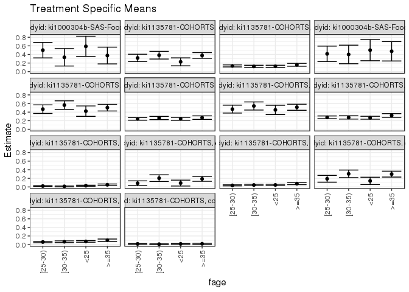

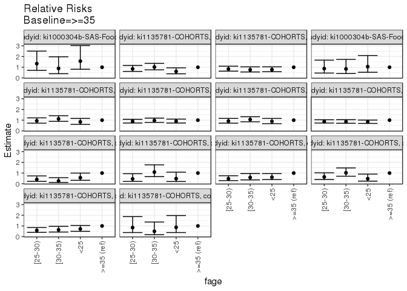

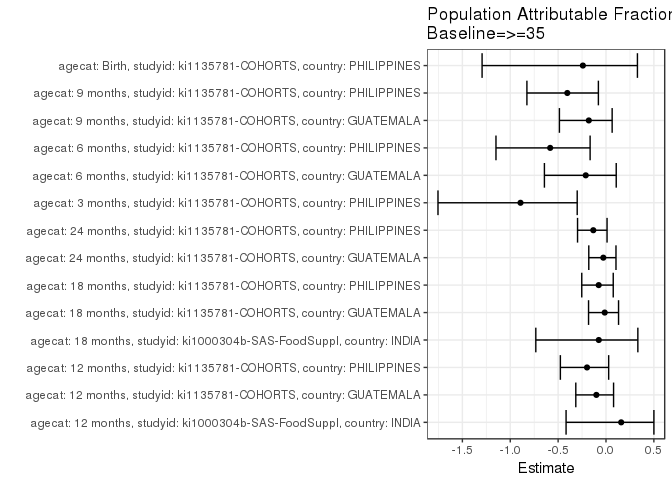

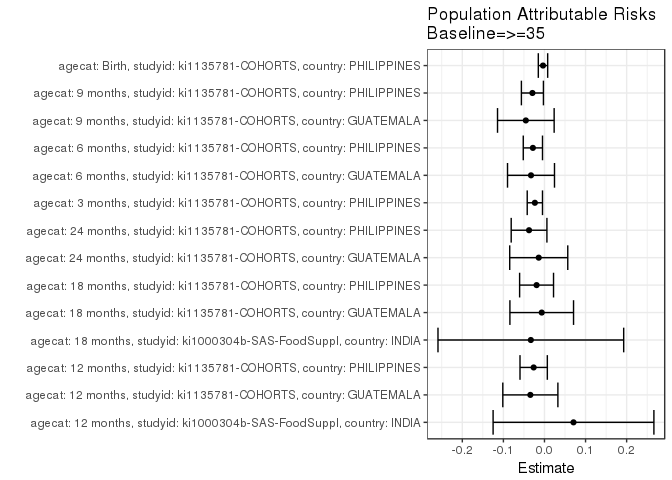

## Results Table

### Parameter: TSM

| agecat | studyid | country | intervention_level | baseline_level | estimate | ci_lower | ci_upper |
| --- | --- | --- | --- | --- | --- | --- | --- |
| Birth | ki1135781-COHORTS | PHILIPPINES | >=35 | NA | 0.0185529 | 0.0071591 | 0.0299466 |
| Birth | ki1135781-COHORTS | PHILIPPINES | <25 | NA | 0.0161692 | 0.0074495 | 0.0248888 |
| Birth | ki1135781-COHORTS | PHILIPPINES | [25-30) | NA | 0.0157233 | 0.0078278 | 0.0236187 |
| Birth | ki1135781-COHORTS | PHILIPPINES | [30-35) | NA | 0.0092736 | 0.0018865 | 0.0166606 |
| 3 months | ki1135781-COHORTS | PHILIPPINES | >=35 | NA | 0.0496183 | 0.0310219 | 0.0682148 |
| 3 months | ki1135781-COHORTS | PHILIPPINES | <25 | NA | 0.0281501 | 0.0162789 | 0.0400214 |
| 3 months | ki1135781-COHORTS | PHILIPPINES | [25-30) | NA | 0.0200893 | 0.0109007 | 0.0292778 |
| 3 months | ki1135781-COHORTS | PHILIPPINES | [30-35) | NA | 0.0129241 | 0.0040248 | 0.0218234 |
| 6 months | ki1135781-COHORTS | GUATEMALA | >=35 | NA | 0.1878453 | 0.1308792 | 0.2448115 |
| 6 months | ki1135781-COHORTS | GUATEMALA | <25 | NA | 0.0895522 | 0.0211036 | 0.1580009 |
| 6 months | ki1135781-COHORTS | GUATEMALA | [25-30) | NA | 0.0851064 | 0.0286336 | 0.1415791 |
| 6 months | ki1135781-COHORTS | GUATEMALA | [30-35) | NA | 0.2038835 | 0.1259907 | 0.2817763 |
| 6 months | ki1135781-COHORTS | PHILIPPINES | >=35 | NA | 0.0766129 | 0.0532012 | 0.1000246 |
| 6 months | ki1135781-COHORTS | PHILIPPINES | <25 | NA | 0.0462185 | 0.0308152 | 0.0616218 |
| 6 months | ki1135781-COHORTS | PHILIPPINES | [25-30) | NA | 0.0359712 | 0.0233305 | 0.0486119 |
| 6 months | ki1135781-COHORTS | PHILIPPINES | [30-35) | NA | 0.0448276 | 0.0279842 | 0.0616710 |
| 9 months | ki1135781-COHORTS | GUATEMALA | >=35 | NA | 0.2982456 | 0.2295974 | 0.3668939 |
| 9 months | ki1135781-COHORTS | GUATEMALA | <25 | NA | 0.1406250 | 0.0553581 | 0.2258919 |
| 9 months | ki1135781-COHORTS | GUATEMALA | [25-30) | NA | 0.1894737 | 0.1105797 | 0.2683677 |
| 9 months | ki1135781-COHORTS | GUATEMALA | [30-35) | NA | 0.3047619 | 0.2166164 | 0.3929074 |
| 9 months | ki1135781-COHORTS | PHILIPPINES | >=35 | NA | 0.1020408 | 0.0752338 | 0.1288478 |
| 9 months | ki1135781-COHORTS | PHILIPPINES | <25 | NA | 0.0738162 | 0.0546871 | 0.0929452 |
| 9 months | ki1135781-COHORTS | PHILIPPINES | [25-30) | NA | 0.0594530 | 0.0434681 | 0.0754379 |
| 9 months | ki1135781-COHORTS | PHILIPPINES | [30-35) | NA | 0.0656304 | 0.0454559 | 0.0858049 |
| 12 months | ki1000304b-SAS-FoodSuppl | INDIA | >=35 | NA | 0.3750000 | 0.1802528 | 0.5697472 |
| 12 months | ki1000304b-SAS-FoodSuppl | INDIA | <25 | NA | 0.5882353 | 0.3530030 | 0.8234676 |
| 12 months | ki1000304b-SAS-FoodSuppl | INDIA | [25-30) | NA | 0.5000000 | 0.3201002 | 0.6798998 |
| 12 months | ki1000304b-SAS-FoodSuppl | INDIA | [30-35) | NA | 0.3333333 | 0.1306092 | 0.5360574 |
| 12 months | ki1135781-COHORTS | GUATEMALA | >=35 | NA | 0.3762376 | 0.3093663 | 0.4431090 |
| 12 months | ki1135781-COHORTS | GUATEMALA | <25 | NA | 0.2278481 | 0.1352642 | 0.3204320 |
| 12 months | ki1135781-COHORTS | GUATEMALA | [25-30) | NA | 0.3185841 | 0.2325929 | 0.4045753 |
| 12 months | ki1135781-COHORTS | GUATEMALA | [30-35) | NA | 0.3826087 | 0.2936919 | 0.4715255 |
| 12 months | ki1135781-COHORTS | PHILIPPINES | >=35 | NA | 0.1591398 | 0.1258846 | 0.1923950 |
| 12 months | ki1135781-COHORTS | PHILIPPINES | <25 | NA | 0.1238938 | 0.0990897 | 0.1486979 |
| 12 months | ki1135781-COHORTS | PHILIPPINES | [25-30) | NA | 0.1331689 | 0.1097809 | 0.1565569 |
| 12 months | ki1135781-COHORTS | PHILIPPINES | [30-35) | NA | 0.1211573 | 0.0939552 | 0.1483594 |
| 18 months | ki1000304b-SAS-FoodSuppl | INDIA | >=35 | NA | 0.4736842 | 0.2478241 | 0.6995443 |
| 18 months | ki1000304b-SAS-FoodSuppl | INDIA | <25 | NA | 0.5000000 | 0.2535330 | 0.7464670 |
| 18 months | ki1000304b-SAS-FoodSuppl | INDIA | [25-30) | NA | 0.4137931 | 0.2334636 | 0.5941226 |
| 18 months | ki1000304b-SAS-FoodSuppl | INDIA | [30-35) | NA | 0.4000000 | 0.1840072 | 0.6159928 |
| 18 months | ki1135781-COHORTS | GUATEMALA | >=35 | NA | 0.5031056 | 0.4257809 | 0.5804303 |
| 18 months | ki1135781-COHORTS | GUATEMALA | <25 | NA | 0.4218750 | 0.3007365 | 0.5430135 |
| 18 months | ki1135781-COHORTS | GUATEMALA | [25-30) | NA | 0.4687500 | 0.3688066 | 0.5686934 |
| 18 months | ki1135781-COHORTS | GUATEMALA | [30-35) | NA | 0.5625000 | 0.4631463 | 0.6618537 |
| 18 months | ki1135781-COHORTS | PHILIPPINES | >=35 | NA | 0.2713004 | 0.2300271 | 0.3125738 |
| 18 months | ki1135781-COHORTS | PHILIPPINES | <25 | NA | 0.2431193 | 0.2102362 | 0.2760023 |
| 18 months | ki1135781-COHORTS | PHILIPPINES | [25-30) | NA | 0.2413793 | 0.2114001 | 0.2713585 |
| 18 months | ki1135781-COHORTS | PHILIPPINES | [30-35) | NA | 0.2626642 | 0.2252955 | 0.3000328 |
| 24 months | ki1135781-COHORTS | GUATEMALA | >=35 | NA | 0.5129534 | 0.4423651 | 0.5835417 |
| 24 months | ki1135781-COHORTS | GUATEMALA | <25 | NA | 0.4512195 | 0.3434059 | 0.5590331 |
| 24 months | ki1135781-COHORTS | GUATEMALA | [25-30) | NA | 0.4690265 | 0.3769216 | 0.5611315 |
| 24 months | ki1135781-COHORTS | GUATEMALA | [30-35) | NA | 0.5420561 | 0.4475579 | 0.6365543 |
| 24 months | ki1135781-COHORTS | PHILIPPINES | >=35 | NA | 0.3205418 | 0.2770746 | 0.3640089 |
| 24 months | ki1135781-COHORTS | PHILIPPINES | <25 | NA | 0.2685185 | 0.2343881 | 0.3026489 |
| 24 months | ki1135781-COHORTS | PHILIPPINES | [25-30) | NA | 0.2785808 | 0.2467229 | 0.3104387 |
| 24 months | ki1135781-COHORTS | PHILIPPINES | [30-35) | NA | 0.2755299 | 0.2370839 | 0.3139758 |

### Parameter: E(Y)

| agecat | studyid | country | intervention_level | baseline_level | estimate | ci_lower | ci_upper |
| --- | --- | --- | --- | --- | --- | --- | --- |
| Birth | ki1135781-COHORTS | PHILIPPINES | NA | NA | 0.0149457 | 0.0148311 | 0.0150602 |
| 3 months | ki1135781-COHORTS | PHILIPPINES | NA | NA | 0.0262118 | 0.0257488 | 0.0266749 |
| 6 months | ki1135781-COHORTS | GUATEMALA | NA | NA | 0.1550562 | 0.1502510 | 0.1598613 |
| 6 months | ki1135781-COHORTS | PHILIPPINES | NA | NA | 0.0483994 | 0.0478532 | 0.0489455 |
| 9 months | ki1135781-COHORTS | GUATEMALA | NA | NA | 0.2528736 | 0.2467831 | 0.2589640 |
| 9 months | ki1135781-COHORTS | PHILIPPINES | NA | NA | 0.0726788 | 0.0721014 | 0.0732563 |
| 12 months | ki1000304b-SAS-FoodSuppl | INDIA | NA | NA | 0.4456522 | 0.4262674 | 0.4650370 |
| 12 months | ki1135781-COHORTS | GUATEMALA | NA | NA | 0.3418468 | 0.3370982 | 0.3465953 |
| 12 months | ki1135781-COHORTS | PHILIPPINES | NA | NA | 0.1328281 | 0.1323027 | 0.1333535 |
| 18 months | ki1000304b-SAS-FoodSuppl | INDIA | NA | NA | 0.4404762 | 0.4319786 | 0.4489738 |
| 18 months | ki1135781-COHORTS | GUATEMALA | NA | NA | 0.4964029 | 0.4920503 | 0.5007555 |
| 18 months | ki1135781-COHORTS | PHILIPPINES | NA | NA | 0.2520695 | 0.2515782 | 0.2525609 |
| 24 months | ki1135781-COHORTS | GUATEMALA | NA | NA | 0.4989899 | 0.4961190 | 0.5018608 |
| 24 months | ki1135781-COHORTS | PHILIPPINES | NA | NA | 0.2830030 | 0.2822615 | 0.2837444 |

### Parameter: RR

| agecat | studyid | country | intervention_level | baseline_level | estimate | ci_lower | ci_upper |
| --- | --- | --- | --- | --- | --- | --- | --- |
| Birth | ki1135781-COHORTS | PHILIPPINES | >=35 | >=35 | 1.0000000 | 1.0000000 | 1.0000000 |
| Birth | ki1135781-COHORTS | PHILIPPINES | <25 | >=35 | 0.8715174 | 0.3848851 | 1.9734270 |
| Birth | ki1135781-COHORTS | PHILIPPINES | [25-30) | >=35 | 0.8474843 | 0.3833644 | 1.8734906 |
| Birth | ki1135781-COHORTS | PHILIPPINES | [30-35) | >=35 | 0.4998454 | 0.1828163 | 1.3666478 |
| 3 months | ki1135781-COHORTS | PHILIPPINES | >=35 | >=35 | 1.0000000 | 1.0000000 | 1.0000000 |
| 3 months | ki1135781-COHORTS | PHILIPPINES | <25 | >=35 | 0.5673335 | 0.3227114 | 0.9973841 |
| 3 months | ki1135781-COHORTS | PHILIPPINES | [25-30) | >=35 | 0.4048764 | 0.2241359 | 0.7313636 |
| 3 months | ki1135781-COHORTS | PHILIPPINES | [30-35) | >=35 | 0.2604697 | 0.1189274 | 0.5704698 |
| 6 months | ki1135781-COHORTS | GUATEMALA | >=35 | >=35 | 1.0000000 | 1.0000000 | 1.0000000 |
| 6 months | ki1135781-COHORTS | GUATEMALA | <25 | >=35 | 0.4767340 | 0.2094850 | 1.0849239 |
| 6 months | ki1135781-COHORTS | GUATEMALA | [25-30) | >=35 | 0.4530663 | 0.2184306 | 0.9397450 |
| 6 months | ki1135781-COHORTS | GUATEMALA | [30-35) | >=35 | 1.0853798 | 0.6664123 | 1.7677484 |
| 6 months | ki1135781-COHORTS | PHILIPPINES | >=35 | >=35 | 1.0000000 | 1.0000000 | 1.0000000 |
| 6 months | ki1135781-COHORTS | PHILIPPINES | <25 | >=35 | 0.6032729 | 0.3838325 | 0.9481692 |
| 6 months | ki1135781-COHORTS | PHILIPPINES | [25-30) | >=35 | 0.4695191 | 0.2947167 | 0.7480004 |
| 6 months | ki1135781-COHORTS | PHILIPPINES | [30-35) | >=35 | 0.5851180 | 0.3605025 | 0.9496830 |
| 9 months | ki1135781-COHORTS | GUATEMALA | >=35 | >=35 | 1.0000000 | 1.0000000 | 1.0000000 |
| 9 months | ki1135781-COHORTS | GUATEMALA | <25 | >=35 | 0.4715074 | 0.2465030 | 0.9018926 |
| 9 months | ki1135781-COHORTS | GUATEMALA | [25-30) | >=35 | 0.6352941 | 0.3947761 | 1.0223481 |
| 9 months | ki1135781-COHORTS | GUATEMALA | [30-35) | >=35 | 1.0218487 | 0.7060814 | 1.4788307 |
| 9 months | ki1135781-COHORTS | PHILIPPINES | >=35 | >=35 | 1.0000000 | 1.0000000 | 1.0000000 |
| 9 months | ki1135781-COHORTS | PHILIPPINES | <25 | >=35 | 0.7233983 | 0.5001689 | 1.0462568 |
| 9 months | ki1135781-COHORTS | PHILIPPINES | [25-30) | >=35 | 0.5826397 | 0.4000797 | 0.8485035 |
| 9 months | ki1135781-COHORTS | PHILIPPINES | [30-35) | >=35 | 0.6431779 | 0.4292588 | 0.9637025 |
| 12 months | ki1000304b-SAS-FoodSuppl | INDIA | >=35 | >=35 | 1.0000000 | 1.0000000 | 1.0000000 |
| 12 months | ki1000304b-SAS-FoodSuppl | INDIA | <25 | >=35 | 1.5686275 | 0.8144440 | 3.0211923 |
| 12 months | ki1000304b-SAS-FoodSuppl | INDIA | [25-30) | >=35 | 1.3333333 | 0.7088543 | 2.5079593 |
| 12 months | ki1000304b-SAS-FoodSuppl | INDIA | [30-35) | >=35 | 0.8888889 | 0.3995101 | 1.9777307 |
| 12 months | ki1135781-COHORTS | GUATEMALA | >=35 | >=35 | 1.0000000 | 1.0000000 | 1.0000000 |
| 12 months | ki1135781-COHORTS | GUATEMALA | <25 | >=35 | 0.6055963 | 0.3886586 | 0.9436222 |
| 12 months | ki1135781-COHORTS | GUATEMALA | [25-30) | >=35 | 0.8467629 | 0.6129236 | 1.1698153 |
| 12 months | ki1135781-COHORTS | GUATEMALA | [30-35) | >=35 | 1.0169336 | 0.7589797 | 1.3625582 |
| 12 months | ki1135781-COHORTS | PHILIPPINES | >=35 | >=35 | 1.0000000 | 1.0000000 | 1.0000000 |
| 12 months | ki1135781-COHORTS | PHILIPPINES | <25 | >=35 | 0.7785219 | 0.5828920 | 1.0398090 |
| 12 months | ki1135781-COHORTS | PHILIPPINES | [25-30) | >=35 | 0.8368047 | 0.6369053 | 1.0994447 |
| 12 months | ki1135781-COHORTS | PHILIPPINES | [30-35) | >=35 | 0.7613264 | 0.5602276 | 1.0346115 |
| 18 months | ki1000304b-SAS-FoodSuppl | INDIA | >=35 | >=35 | 1.0000000 | 1.0000000 | 1.0000000 |
| 18 months | ki1000304b-SAS-FoodSuppl | INDIA | <25 | >=35 | 1.0555556 | 0.5316637 | 2.0956809 |
| 18 months | ki1000304b-SAS-FoodSuppl | INDIA | [25-30) | >=35 | 0.8735632 | 0.4578835 | 1.6666089 |
| 18 months | ki1000304b-SAS-FoodSuppl | INDIA | [30-35) | >=35 | 0.8444444 | 0.4108829 | 1.7354979 |
| 18 months | ki1135781-COHORTS | GUATEMALA | >=35 | >=35 | 1.0000000 | 1.0000000 | 1.0000000 |
| 18 months | ki1135781-COHORTS | GUATEMALA | <25 | >=35 | 0.8385417 | 0.6054521 | 1.1613672 |
| 18 months | ki1135781-COHORTS | GUATEMALA | [25-30) | >=35 | 0.9317130 | 0.7163658 | 1.2117958 |
| 18 months | ki1135781-COHORTS | GUATEMALA | [30-35) | >=35 | 1.1180556 | 0.8846659 | 1.4130174 |
| 18 months | ki1135781-COHORTS | PHILIPPINES | >=35 | >=35 | 1.0000000 | 1.0000000 | 1.0000000 |
| 18 months | ki1135781-COHORTS | PHILIPPINES | <25 | >=35 | 0.8961256 | 0.7310760 | 1.0984371 |
| 18 months | ki1135781-COHORTS | PHILIPPINES | [25-30) | >=35 | 0.8897122 | 0.7310682 | 1.0827823 |
| 18 months | ki1135781-COHORTS | PHILIPPINES | [30-35) | >=35 | 0.9681671 | 0.7861252 | 1.1923642 |
| 24 months | ki1135781-COHORTS | GUATEMALA | >=35 | >=35 | 1.0000000 | 1.0000000 | 1.0000000 |
| 24 months | ki1135781-COHORTS | GUATEMALA | <25 | >=35 | 0.8796502 | 0.6676685 | 1.1589351 |
| 24 months | ki1135781-COHORTS | GUATEMALA | [25-30) | >=35 | 0.9143649 | 0.7194148 | 1.1621433 |
| 24 months | ki1135781-COHORTS | GUATEMALA | [30-35) | >=35 | 1.0567356 | 0.8462702 | 1.3195432 |
| 24 months | ki1135781-COHORTS | PHILIPPINES | >=35 | >=35 | 1.0000000 | 1.0000000 | 1.0000000 |
| 24 months | ki1135781-COHORTS | PHILIPPINES | <25 | >=35 | 0.8377021 | 0.6956177 | 1.0088082 |
| 24 months | ki1135781-COHORTS | PHILIPPINES | [25-30) | >=35 | 0.8690937 | 0.7278266 | 1.0377798 |
| 24 months | ki1135781-COHORTS | PHILIPPINES | [30-35) | >=35 | 0.8595756 | 0.7075905 | 1.0442058 |

### Parameter: PAR

| agecat | studyid | country | intervention_level | baseline_level | estimate | ci_lower | ci_upper |
| --- | --- | --- | --- | --- | --- | --- | --- |
| Birth | ki1135781-COHORTS | PHILIPPINES | >=35 | NA | -0.0036072 | -0.0150015 | 0.0077871 |
| 3 months | ki1135781-COHORTS | PHILIPPINES | >=35 | NA | -0.0234065 | -0.0420087 | -0.0048042 |
| 6 months | ki1135781-COHORTS | GUATEMALA | >=35 | NA | -0.0327891 | -0.0899576 | 0.0243793 |
| 6 months | ki1135781-COHORTS | PHILIPPINES | >=35 | NA | -0.0282135 | -0.0516316 | -0.0047954 |
| 9 months | ki1135781-COHORTS | GUATEMALA | >=35 | NA | -0.0453721 | -0.1142899 | 0.0235458 |
| 9 months | ki1135781-COHORTS | PHILIPPINES | >=35 | NA | -0.0293620 | -0.0561752 | -0.0025488 |
| 12 months | ki1000304b-SAS-FoodSuppl | INDIA | >=35 | NA | 0.0706522 | -0.1250575 | 0.2663618 |
| 12 months | ki1135781-COHORTS | GUATEMALA | >=35 | NA | -0.0343909 | -0.1014306 | 0.0326489 |
| 12 months | ki1135781-COHORTS | PHILIPPINES | >=35 | NA | -0.0263117 | -0.0595711 | 0.0069476 |
| 18 months | ki1000304b-SAS-FoodSuppl | INDIA | >=35 | NA | -0.0332080 | -0.2592279 | 0.1928119 |
| 18 months | ki1135781-COHORTS | GUATEMALA | >=35 | NA | -0.0067027 | -0.0841498 | 0.0707444 |
| 18 months | ki1135781-COHORTS | PHILIPPINES | >=35 | NA | -0.0192309 | -0.0605072 | 0.0220454 |
| 24 months | ki1135781-COHORTS | GUATEMALA | >=35 | NA | -0.0139635 | -0.0846101 | 0.0566832 |
| 24 months | ki1135781-COHORTS | PHILIPPINES | >=35 | NA | -0.0375388 | -0.0810123 | 0.0059347 |

### Parameter: PAF

| agecat | studyid | country | intervention_level | baseline_level | estimate | ci_lower | ci_upper |
| --- | --- | --- | --- | --- | --- | --- | --- |
| Birth | ki1135781-COHORTS | PHILIPPINES | >=35 | NA | -0.2413560 | -1.2941792 | 0.3283154 |
| 3 months | ki1135781-COHORTS | PHILIPPINES | >=35 | NA | -0.8929729 | -1.7548281 | -0.3007514 |
| 6 months | ki1135781-COHORTS | GUATEMALA | >=35 | NA | -0.2114661 | -0.6432427 | 0.1068574 |
| 6 months | ki1135781-COHORTS | PHILIPPINES | >=35 | NA | -0.5829312 | -1.1491466 | -0.1658912 |
| 9 months | ki1135781-COHORTS | GUATEMALA | >=35 | NA | -0.1794258 | -0.4865499 | 0.0642458 |
| 9 months | ki1135781-COHORTS | PHILIPPINES | >=35 | NA | -0.4039962 | -0.8260426 | -0.0794957 |
| 12 months | ki1000304b-SAS-FoodSuppl | INDIA | >=35 | NA | 0.1585366 | -0.4169855 | 0.5003049 |
| 12 months | ki1135781-COHORTS | GUATEMALA | >=35 | NA | -0.1006032 | -0.3153955 | 0.0791155 |
| 12 months | ki1135781-COHORTS | PHILIPPINES | >=35 | NA | -0.1980884 | -0.4765868 | 0.0278825 |
| 18 months | ki1000304b-SAS-FoodSuppl | INDIA | >=35 | NA | -0.0753912 | -0.7330631 | 0.3327039 |
| 18 months | ki1135781-COHORTS | GUATEMALA | >=35 | NA | -0.0135026 | -0.1821761 | 0.1311045 |
| 18 months | ki1135781-COHORTS | PHILIPPINES | >=35 | NA | -0.0762921 | -0.2531571 | 0.0756109 |
| 24 months | ki1135781-COHORTS | GUATEMALA | >=35 | NA | -0.0279835 | -0.1797834 | 0.1042847 |
| 24 months | ki1135781-COHORTS | PHILIPPINES | >=35 | NA | -0.1326446 | -0.2971712 | 0.0110143 |